# act_report

## Data Analysis Report

#### Reporting Requirements:

- Create a **250-word-minimum written report** called *act_report.pdf or act_report.html* that communicates the insights and displays the visualization(s) produced from your wrangled data. This is to be framed as an external document, like a blog post or magazine article, for example.

#### Summary of questions

*During the data wrangling process, I came up with 4 questions that I thought would be worth-exploring:*

> 1. What is the relationship between favourite_count and retweet_count on Twitter?
> 2. What are the sources of the tweets?
> 3. From the result of the first algorithm to predict the breed of the dog via images, how many images can be predicted with at least 95% confidence and what are they top 5 breeds from the prediction?
> 4. Among the 3 prediction algorithms, which one is more reliable?

# Data Analysis

#### Question 1: What is the relationship between favourite_count and retweet_count on Twitter?

```python
# We want to understand the relationship between retweet and favourite count
```

```
The correlation coefficient between retweet and favourite count is 0.861987708294
```

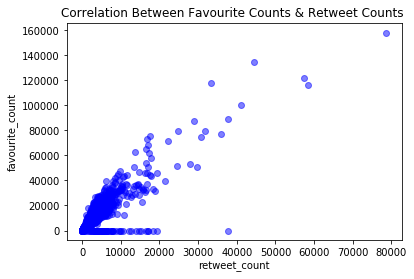

#### Insight 1(a)

> - The scatter plot above shows that favourite counts and retweet counts are positively correlated.
> - The correlation coefficient between retweet and favourite counts is 0.86, showing a strong positively correlated relationship.
> - Some retweets have no favorite_count.

```python
# The statistics below tell us more whether it is useful to use retweet as an indepedent
# variable affecting the number of favourite counts on Twitter
```

OLS Regression Results

| Dep. Variable: | favorite_count | R-squared: | 0.743 |
| --- | --- | --- | --- |
| Model: | OLS | Adj. R-squared: | 0.743 |
| Method: | Least Squares | F-statistic: | 5948. |
| Date: | Wed, 04 Mar 2020 | Prob (F-statistic): | 0.00 |
| Time: | 11:36:28 | Log-Likelihood: | -20892. |
| No. Observations: | 2059 | AIC: | 4.179e+04 |
| Df Residuals: | 2057 | BIC: | 4.180e+04 |
| Df Model: | 1 |  |  |
| Covariance Type: | nonrobust |  |  |

|  | coef | std err | t | P>\|t\| | [0.025 | 0.975] |
| --- | --- | --- | --- | --- | --- | --- |
| intercept | 2054.6223 | 156.851 | 13.099 | 0.000 | 1747.019 | 2362.225 |
| retweet_count | 2.2989 | 0.030 | 77.121 | 0.000 | 2.240 | 2.357 |

| Omnibus: | 1212.289 | Durbin-Watson: | 1.182 |
| --- | --- | --- | --- |
| Prob(Omnibus): | 0.000 | Jarque-Bera (JB): | 88439.298 |
| Skew: | -1.951 | Prob(JB): | 0.00 |
| Kurtosis: | 34.869 | Cond. No. | 6.06e+03 |

#### Insight (1b)

> - In the regression model above, retweet_count is the independent variable and the favourite_count is the dependent variable.
> - The regression model above is able to explain 74.3% of the population.
> - The P-value of the retweet_count is 0.00, which means that we can reject the null hypothesis of retweet_count having no effect on favourite_count.
> - On average, every one unit of retweet_count leads to an increase of favourite_count by 2.298 unit.

#### Question 2: What are the sources of the tweets?

**Sources and the counts:**

- Twitter for iPhone : 2019
- Twitter Web Client : 30
- TweetDeck : 10

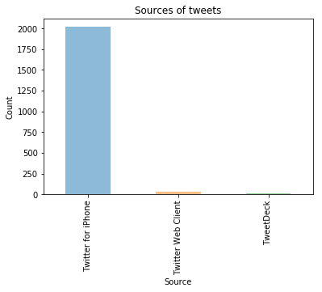

> **Insight 2**
> - The tweets are predominantly from iPhones.
> - There are barely any users from the Twitter website or TweetDeck.
> - However, it seems like the data is lacking information about users who are not using iPhone. There could be a chance that all mobile users have been grouped up as iPhone but this is worth investigating.

#### Question 3: From the result of the first algorithm to predict the breed of the dog via images, how many images can be predicted with at least 95% confidence and what are they top 5 breeds from the prediction?

> **Insight 3**
> - From the 1st algorithm predicting the breed of dogs, only 188 images could be predicted with at least 95% confidence.
> - When dogs are holding other objects, it seems like all the predictions won't be able to differentiate between objects and dogs from the image as each of the 3 algorithms has predicted at least 500 non-dog objects.
> - Only about 9% of images can be predicted with at least 95% confidence.
> - The top 5 breeds from the prediction are pug (21), samoyed (19),pembroke (19), golden_retriever (18) and pomeranian (13).

#### Question 4: Among the 3 prediction algorithms, which one is more reliable?

> **Insight 4**
> - Among the 3 algorithms, it seems that the first algorithm is more reliable in predicting the breed of dogs via its images as it is able to predict 9% of images with at least 95% confidence, while the other two algorithms do have any prediction with more than 95% confidence.